# INSIGHTS FROM TEST WICKETS

## Introduction

```
Test cricket is the traditional format of cricket. Though there are some formats in cricket, Test format has a unique place in the cricket world for its uniqueness. Unlike other format, test cricket really tests the temperament, mindset and personality of the player.
The dataset we are going to look forth is 'Test Wickets' dataset. It is a rank based dataset and the rank is based on wickets. It has players from different countries and some data about them.
We are going to see insights extracted from this data, what the data actually says, trends and patterns etc.,
Let's dive into this project.
```

## Importing the required modules

```python
import pandas as pd
import matplotlib.pyplot as plt
import numpy as np
import seaborn as sns
```

These are Python libraries which is going to aid us in extracting the insights.

## Opening the File

```python
rdf = pd.read_csv('Test wickets.csv')
rdf
```

|  | Rank | Player | Country | Career Span | Matches | Innings | Balls | Runs | Wickets | Average | Economy | Strike Rate | 5 | 10 | Best Figures |
| --- | --- | --- | --- | --- | --- | --- | --- | --- | --- | --- | --- | --- | --- | --- | --- |
| 0 | 1 | M Muralidaran | SL | 18 | 133 | 230 | 44039 | 18180 | 800 | 22.72 | 2.47 | 55.0 | 67 | 22 | 9/51 |
| 1 | 2 | SK Warne | AUS | 15 | 145 | 273 | 40705 | 17995 | 708 | 25.41 | 2.65 | 57.4 | 37 | 10 | 8/71 |
| 2 | 3 | JM Anderson | ENG | 19 | 175 | 325 | 37505 | 17491 | 667 | 26.22 | 2.79 | 56.2 | 32 | 3 | 7/42 |
| 3 | 4 | A Kumble | INDIA | 18 | 132 | 236 | 40850 | 18355 | 619 | 29.65 | 2.69 | 65.9 | 35 | 8 | 10/74 |
| 4 | 5 | SCJ Broad | ENG | 15 | 159 | 293 | 31982 | 15720 | 566 | 27.77 | 2.94 | 56.5 | 19 | 3 | 8/15 |
| ... | ... | ... | ... | ... | ... | ... | ... | ... | ... | ... | ... | ... | ... | ... | ... |
| 74 | 75 | MG Hughes | AUS | 9 | 53 | 97 | 12285 | 6017 | 212 | 28.38 | 2.93 | 57.9 | 7 | 1 | 8/87 |
| 75 | 76 | SCG MacGill | AUS | 10 | 44 | 85 | 11237 | 6038 | 208 | 29.02 | 3.22 | 54.0 | 12 | 2 | 8/108 |
| 76 | 77 | Saqlain Mushtaq | PAK | 9 | 49 | 86 | 14070 | 6206 | 208 | 29.83 | 2.64 | 67.6 | 13 | 3 | 8/164 |
| 77 | 78 | AME Roberts | WI | 9 | 47 | 90 | 11135 | 5174 | 202 | 25.61 | 2.78 | 55.1 | 11 | 2 | 7/54 |
| 78 | 79 | JA Snow | ENG | 11 | 49 | 93 | 12021 | 5387 | 202 | 26.66 | 2.68 | 59.5 | 8 | 1 | 7/40 |

79 rows × 15 columns

#### (The Rank is based on Wickets. So, the order of entire data order is based on how many Wickets a player has)

## Preparing the data

```python
rdf.info()
```

```
<class 'pandas.core.frame.DataFrame'>
RangeIndex: 79 entries, 0 to 78
Data columns (total 15 columns):
 #   Column        Non-Null Count  Dtype
---  ------        --------------  -----
 0   Rank          79 non-null     int64
 1   Player        79 non-null     object
 2   Country       79 non-null     object
 3   Career Span   79 non-null     int64
 4   Matches       79 non-null     int64
 5   Innings       79 non-null     int64
 6   Balls         79 non-null     int64
 7   Runs          79 non-null     int64
 8   Wickets       79 non-null     int64
 9   Average       79 non-null     float64
 10  Economy       79 non-null     float64
 11  Strike Rate   79 non-null     float64
 12  5             79 non-null     int64
 13  10            79 non-null     int64
 14  Best Figures  79 non-null     object
dtypes: float64(3), int64(9), object(3)
memory usage: 9.4+ KB
```

```python
print(rdf.shape)
print(rdf.size)
```

```
(79, 15)
1185
```

There are 79 rows and 15 columns.

```python
rdf.isna().sum().sum()
```

```
0
```

There are no null values in the data.

```python
rawdf = rdf.drop(['5', '10', 'Average', 'Strike Rate'], axis = 1)
rawdf
```

|  | Rank | Player | Country | Career Span | Matches | Innings | Balls | Runs | Wickets | Economy | Best Figures |
| --- | --- | --- | --- | --- | --- | --- | --- | --- | --- | --- | --- |
| 0 | 1 | M Muralidaran | SL | 18 | 133 | 230 | 44039 | 18180 | 800 | 2.47 | 9/51 |
| 1 | 2 | SK Warne | AUS | 15 | 145 | 273 | 40705 | 17995 | 708 | 2.65 | 8/71 |
| 2 | 3 | JM Anderson | ENG | 19 | 175 | 325 | 37505 | 17491 | 667 | 2.79 | 7/42 |
| 3 | 4 | A Kumble | INDIA | 18 | 132 | 236 | 40850 | 18355 | 619 | 2.69 | 10/74 |
| 4 | 5 | SCJ Broad | ENG | 15 | 159 | 293 | 31982 | 15720 | 566 | 2.94 | 8/15 |
| ... | ... | ... | ... | ... | ... | ... | ... | ... | ... | ... | ... |
| 74 | 75 | MG Hughes | AUS | 9 | 53 | 97 | 12285 | 6017 | 212 | 2.93 | 8/87 |
| 75 | 76 | SCG MacGill | AUS | 10 | 44 | 85 | 11237 | 6038 | 208 | 3.22 | 8/108 |
| 76 | 77 | Saqlain Mushtaq | PAK | 9 | 49 | 86 | 14070 | 6206 | 208 | 2.64 | 8/164 |
| 77 | 78 | AME Roberts | WI | 9 | 47 | 90 | 11135 | 5174 | 202 | 2.78 | 7/54 |
| 78 | 79 | JA Snow | ENG | 11 | 49 | 93 | 12021 | 5387 | 202 | 2.68 | 7/40 |

79 rows × 11 columns

The data is cleaned and prepared and ready for analysis.

## Number of Players per Country in the data

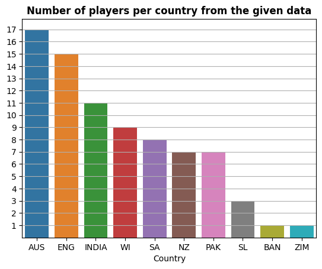

```python
worldeco = round((rawdf.groupby('Country')['Economy'].mean().sort_values(ascending = True)),2)
plperc = rawdf.groupby('Country')['Player'].count().sort_values(ascending = False)
plplt = sns.barplot(x = plperc.index, y = plperc.values)
plplt.set_yticks([s for s in range(1,18)])
plt.grid(axis = 'y')
plt.title('Number of players per country from the given data', fontweight= 'bold')
```

Number of players per country unevenly distributed.

Australia has more number of players in the data followed by England, India and 7 other countries. Bangladesh and Zimbabwe has only one bowler each.

## Wickets per Country

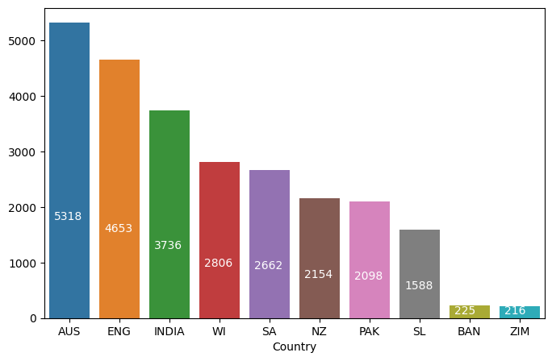

```python
wicpc = rawdf.groupby('Country')['Wickets'].sum().sort_values(ascending = False)
plt.figure(figsize=(8,5))
wipl = sns.barplot(x= wicpc.index, y = wicpc.values)
for i in wipl.patches:
    wipl.text(i.get_x()+0.1, i.get_height()/3, str(int(i.get_height())), color = 'white')
```

Wickets per Country is also unevenlly distributed.

The order is same as the previous plot. This shows the similarity that When a country has higher number of players, It has more Wickets and vice versa.

Australia tops with 5318 Wickets followed by England, India and 7 other Countries.

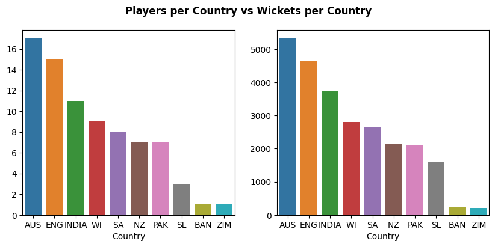

```python
fig,axes = plt.subplots(1,2, figsize=(10,4))
fig.suptitle('Players per Country vs Wickets per Country', fontweight = 'bold')
sns.barplot(ax = axes[0], x = plperc.index, y = plperc.values)

sns.barplot(ax = axes[1], x = wicpc.index, y = wicpc.values)
```

The similarities between both the plots are vivid. It shows more the players more the wickets irrespective of the country.

## Distribution of Wickets

```python
rawdf['Wickets'].describe()
```

```
count     79.000000
mean     322.227848
std      123.607832
min      202.000000
25%      235.500000
50%      287.000000
75%      374.500000
max      800.000000
Name: Wickets, dtype: float64
```

```python
wicdis = sorted(rawdf['Wickets'])
q1,q3 = np.percentile(wicdis,[25,75])
iqr = q3-q1
lowfen = q1-(1.5*iqr)
hifen = q3+(1.5*iqr)
print("The lower and upper fence of the Wickets distribution are {} and {} respectively.".format(lowfen, hifen))
```

```
The lower and upper fence of the Wickets distribution are 27.0 and 583.0 respectively.
```

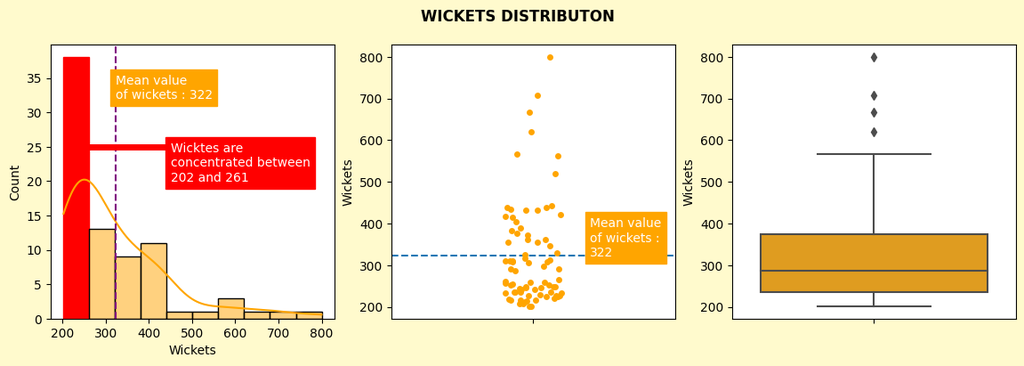

```python
fig,axes = plt.subplots(1,3, figsize = (14,4))
fig.suptitle('WICKETS DISTRIBUTON', fontweight = 'bold')
fig.set_facecolor('lemonchiffon')
sns.histplot(ax = axes[0], x=rawdf["Wickets"], color = 'orange', kde = True).text(rawdf['Wickets'].mean(), 32, 'Mean value\nof wickets : '+str(round(rawdf['Wickets'].mean())), backgroundcolor = 'orange', color = 'white' )
axes[0].axvline(rawdf['Wickets'].mean(), linestyle = '--', color = 'purple')
for i in axes[0].patches:
    if i.get_height()>35:
        i.set_color('red')
        inf1,inf2 = int(i.get_x()), int(i.get_x()+i.get_width())
axes[0].axhline(y = 25, xmin = 0.1, xmax = 0.5, linewidth = 5, color = 'red')
axes[0].text(450,20, "Wicktes are\nconcentrated between\n{} and {}".format(inf1,inf2), backgroundcolor = 'red', color = 'white')

sns.stripplot(ax = axes[1], y=rawdf.Wickets, color = 'orange')
axes[1].axhline(rawdf['Wickets'].mean(), linestyle = '--')
axes[1].text(0.2, rawdf['Wickets'].mean(), 'Mean value\nof wickets :\n'+str(round(rawdf['Wickets'].mean())), backgroundcolor = 'orange', color = 'white' )

sns.boxplot(ax = axes[2], y=rawdf.Wickets, color = 'orange')
```

The plot is skewed towards right and it resembles log normal distribution. The Skewness indicates that only few can become best by having many wickets. The Wickets are highly concentrated(red shaded area) between 202 and 261.

## Top 10 Wicket taking bowlers from the data (or Top 10 Rankholders)

```python
t10 = rawdf.head(10)
t10
```

|  | Rank | Player | Country | Career Span | Matches | Innings | Balls | Runs | Wickets | Economy | Best Figures |
| --- | --- | --- | --- | --- | --- | --- | --- | --- | --- | --- | --- |
| 0 | 1 | M Muralidaran | SL | 18 | 133 | 230 | 44039 | 18180 | 800 | 2.47 | 9/51 |
| 1 | 2 | SK Warne | AUS | 15 | 145 | 273 | 40705 | 17995 | 708 | 2.65 | 8/71 |
| 2 | 3 | JM Anderson | ENG | 19 | 175 | 325 | 37505 | 17491 | 667 | 2.79 | 7/42 |
| 3 | 4 | A Kumble | INDIA | 18 | 132 | 236 | 40850 | 18355 | 619 | 2.69 | 10/74 |
| 4 | 5 | SCJ Broad | ENG | 15 | 159 | 293 | 31982 | 15720 | 566 | 2.94 | 8/15 |
| 5 | 6 | GD McGrath | AUS | 14 | 124 | 243 | 29248 | 12186 | 563 | 2.49 | 8/24 |
| 6 | 7 | CA Walsh | WI | 17 | 132 | 242 | 30019 | 12688 | 519 | 2.53 | 7/37 |
| 7 | 8 | R Ashwin | INDIA | 11 | 86 | 162 | 23089 | 10666 | 442 | 2.77 | 7/59 |
| 8 | 9 | DW Steyn | SA | 15 | 93 | 171 | 18608 | 10077 | 439 | 3.24 | 7/51 |
| 9 | 10 | NM Lyon | AUS | 11 | 110 | 207 | 28583 | 14047 | 438 | 2.94 | 8/50 |

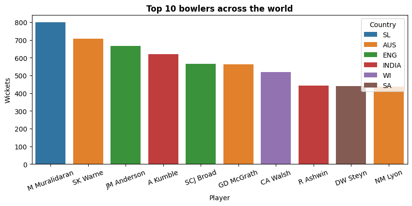

```python
plt.figure(figsize=(10,4))
pt10 = sns.barplot(x= t10['Player'], y = t10['Wickets'], hue = t10['Country'], dodge = False)
plt.xticks(rotation = 20)
plt.title('Top 10 bowlers across the world', fontweight = 'bold')
plt.show()
```

Muthaiah Muralidaran from Sri Lanka Tops the list with highest wickets.

Australia has 3 bowlers, England and India has 2 bowlers each and Sri Lanka, West Indies, South Africa have 1 bowler each in the Top 10 list.

## 500 Wickets club

```python
wic500 = rawdf.loc[:,['Country','Player', 'Wickets']][rawdf.Wickets>499].groupby(['Country','Player','Wickets'])
wic500.first()
```

| Country | Player | Wickets |
| --- | --- | --- |
| AUS | GD McGrath | 563 |
|  | SK Warne | 708 |
| ENG | JM Anderson | 667 |
|  | SCJ Broad | 566 |
| INDIA | A Kumble | 619 |
| SL | M Muralidaran | 800 |
| WI | CA Walsh | 519 |

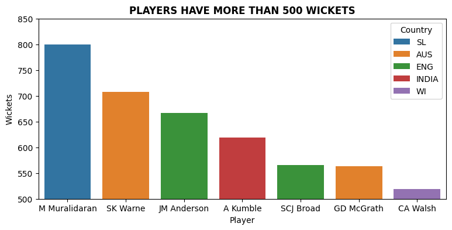

```python
d = rawdf[rawdf['Wickets']>499][['Player','Country','Wickets']]
plt.figure(figsize=(9,4))
wi5 = sns.barplot(x= 'Player', y = 'Wickets', hue= 'Country', data= d, dodge= False)
plt.ylim([500,850])
plt.title("PLAYERS HAVE MORE THAN 500 WICKETS", fontweight='bold')
plt.show()
```

There are 7 bowlers in 500 wickets club from which Australia and England has 2 bowlers each.

## Top 10 Economical Bowlers in the world

```python
top10eco = rawdf.sort_values(by= 'Economy', ascending = True).head(10)
top10eco[['Rank', 'Player', 'Country', 'Economy']]
```

|  | Rank | Player | Country | Economy |
| --- | --- | --- | --- | --- |
| 34 | 35 | LR Gibbs | WI | 1.98 |
| 36 | 37 | DL Underwood | ENG | 2.10 |
| 49 | 50 | R Benaud | AUS | 2.10 |
| 40 | 41 | BS Bedi | INDIA | 2.14 |
| 70 | 71 | CV Grimmett | AUS | 2.16 |
| 56 | 57 | AV Bedser | ENG | 2.21 |
| 59 | 60 | GS Sobers | WI | 2.22 |
| 16 | 17 | CEL Ambrose | WI | 2.30 |
| 63 | 64 | RR Lindwall | AUS | 2.30 |
| 46 | 47 | JB Statham | ENG | 2.33 |

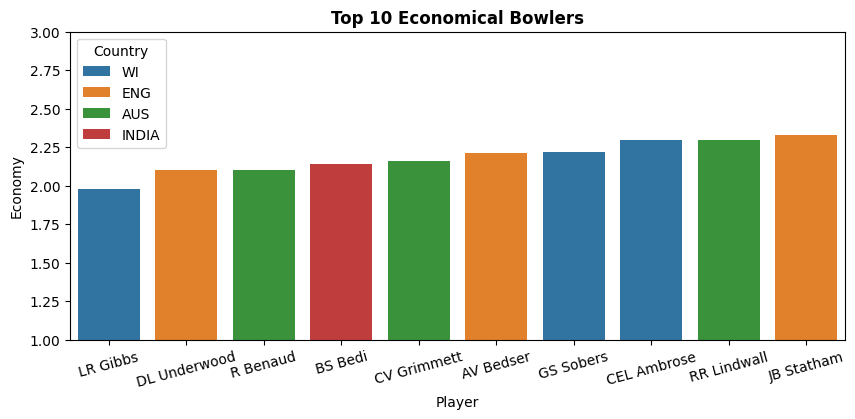

```python
plt.figure(figsize=(10,4))

epl = sns.barplot(x= 'Player', y = 'Economy', data = top10eco, hue= 'Country', dodge = False)
plt.ylim([1.0,3.0])
plt.xticks(rotation = 15)
plt.title('Top 10 Economical Bowlers', fontweight = 'bold')
plt.show()
```

LR Gibbs from West Indies is the most Economical Test bowler.

West Indies, England, Australia has 3 bowlers each. India has only one bowler.

## Economy rates distribution

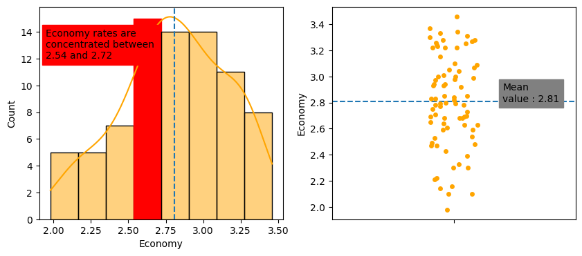

```python
fig,axes = plt.subplots(1,2, figsize = (10,4))
sns.histplot(ax= axes[0], x = rawdf.Economy, color = 'orange', kde = True)
for i in axes[0].patches:
    if i.get_height() > 14:
        i.set_color('red')
        ein1, ein2 = round((i.get_x()),2), round((i.get_x() + i.get_width()),2)
axes[0].axhline(13, xmin = 0.3, xmax = 0.4, linewidth = 5, color = 'red')
axes[0].text(1.95, 12, 'Economy rates are\nconcentrated between\n{} and {}'.format(ein1, ein2), backgroundcolor = 'red')
axes[0].axvline(rawdf.Economy.mean(), linestyle = '--')

sns.stripplot(ax = axes[1], y = rawdf.Economy, color = 'orange')
axes[1].axhline(rawdf.Economy.mean(), linestyle = '--')
axes[1].text(0.2, rawdf.Economy.mean(), 'Mean\nvalue : {}'.format(round(rawdf.Economy.mean(),2)), backgroundcolor = 'grey')
```

The distribution is more likely a normal distribution. The mean is almost closer to the higher concentrated area.

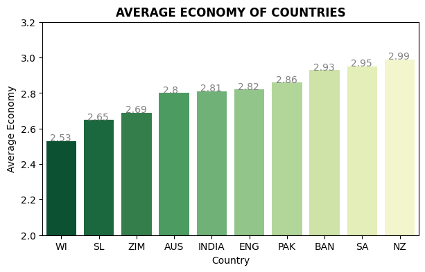

```python
plt.figure(figsize=(7,4))
ecc = sns.barplot(x= worldeco.index, y=worldeco.values, palette = 'YlGn_r')
plt.ylim([2,3.2])
plt.ylabel('Average Economy')
plt.xticks(rotation = 0)
for i in ecc.patches:
    ecc.text(i.get_x()+0.1, i.get_height(), str(i.get_height()), color = 'grey')
plt.title("AVERAGE ECONOMY OF COUNTRIES", fontweight = 'bold')
plt.show()
```

West Indies bowlers are Economical. But this is a rough plot as the numbers are in average and the number of players are largely uneven as Zimbabwe and Bangladesh has only one bowler each whereas Australia has 17 bowlers.

## Distribution of other features

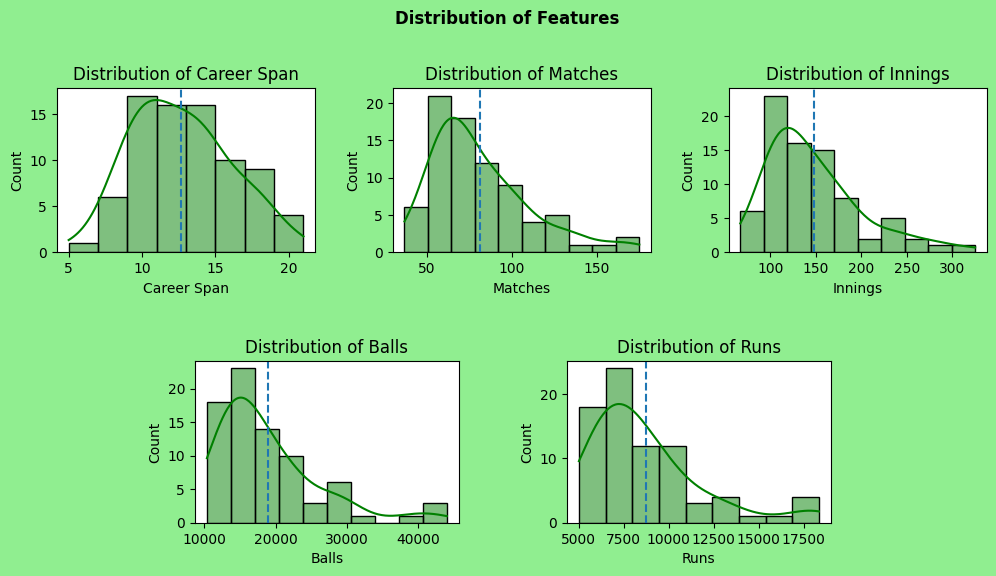

```python
fig, axes = plt.subplots(2,3, figsize=(12,6))
fig.suptitle('Distribution of Features', fontweight = 'bold')
fig.set_facecolor('lightgreen')
plt.subplots_adjust(top = 0.85, hspace = 0.7, wspace = 0.3)
sns.histplot(ax= axes[0,0], x = rawdf['Career Span'], color = 'green', kde = True).set_title('Distribution of Career Span')
axes[0,0].axvline(rawdf['Career Span'].mean(), linestyle= '--')
sns.histplot(ax= axes[0,1], x = rawdf['Matches'], color = 'green', kde = True).set_title('Distribution of Matches')
axes[0,1].axvline(rawdf['Matches'].mean(), linestyle= '--')
sns.histplot(ax= axes[0,2], x = rawdf['Innings'], color = 'green', kde = True).set_title('Distribution of Innings')
axes[0,2].axvline(rawdf['Innings'].mean(), linestyle= '--')
sns.histplot(ax= axes[1,0], x= rawdf['Balls'], color = 'green', kde = True).set_title('Distribution of Balls')
axes[1,0].axvline(rawdf['Balls'].mean(), linestyle= '--')
axes[1,0].set_position([0.24,0.125,0.220, 0.270])
sns.histplot(ax= axes[1,1], x= rawdf['Runs'], color = 'green', kde = True).set_title('Distribution of Runs')
axes[1,1].set_position([0.55, 0.125, 0.220, 0.270])
axes[1,1].axvline(rawdf['Runs'].mean(), linestyle= '--')
axes[1,2].set_visible(False)
```

Mostly all the plots are right skewed.

The lower values are highly distributed and the higher values are hardly distributed.

## Tops

```python
topwc = rawdf[['Wickets','Country','Player']][rawdf['Wickets']== rawdf['Wickets'].max()].squeeze()
topra = rawdf[['Rank','Country','Player']][rawdf['Rank']== rawdf['Rank'].min()].squeeze()
topcs = rawdf[['Career Span','Country','Player']][rawdf['Career Span']== rawdf['Career Span'].max()].squeeze()
topmat = rawdf[['Matches','Country','Player']][rawdf['Matches']== rawdf['Matches'].max()].squeeze()
topin = rawdf[['Innings','Country','Player']][rawdf['Innings']== rawdf['Innings'].max()].squeeze()
topballs = rawdf[['Balls','Country','Player']][rawdf['Balls']== rawdf['Balls'].max()].squeeze()
tope = rawdf[['Economy','Country','Player']][rawdf['Economy']== rawdf['Economy'].min()].squeeze()
toprun = rawdf[['Runs','Country','Player']][rawdf['Runs']== rawdf['Runs'].max()].squeeze()
lesrun = rawdf[['Runs','Country','Player']][rawdf['Runs']== rawdf['Runs'].min()].squeeze()
```

```python
top = pd.DataFrame({'Top Rank': [topra.Rank, topra.Player, topra.Country],
                    'Most Wickets Taken': [topwc.Wickets, topwc.Player, topwc.Country],
                    'Most Economical Bowler': [tope.Economy, tope.Player, tope.Country],
                    'Most Experienced Player': [topcs['Career Span'], topcs.Player, topcs.Country],
                    'Most Matches Played': [topmat.Matches, topmat.Player, topmat.Country],
                    'Most Innings Played': [topin.Innings, topin.Player, topin.Country],
                    'Most Balls Bowled': [topballs.Balls, topballs.Player, topballs.Country],
                    'Least Runs Given': [lesrun.Runs, lesrun.Player, lesrun.Country]}, index = ['Stats', 'Player', 'Country'])
tops = top.T
tops
```

|  | Stats | Player | Country |
| --- | --- | --- | --- |
| Top Rank | 1 | M Muralidaran | SL |
| Most Wickets Taken | 800 | M Muralidaran | SL |
| Most Economical Bowler | 1.98 | LR Gibbs | WI |
| Most Experienced Player | 21 | Imran Khan | PAK |
| Most Matches Played | 175 | JM Anderson | ENG |
| Most Innings Played | 325 | JM Anderson | ENG |
| Most Balls Bowled | 44039 | M Muralidaran | SL |
| Least Runs Given | 5000 | VD Philander | SA |

The above table shows the best of all the features.

## Indian Bowlers record

```python
ind = rawdf[rawdf['Country']=='INDIA']
display(ind)
print(ind.shape[0],'records')
```

|  | Rank | Player | Country | Career Span | Matches | Innings | Balls | Runs | Wickets | Economy | Best Figures |
| --- | --- | --- | --- | --- | --- | --- | --- | --- | --- | --- | --- |
| 3 | 4 | A Kumble | INDIA | 18 | 132 | 236 | 40850 | 18355 | 619 | 2.69 | 10/74 |
| 7 | 8 | R Ashwin | INDIA | 11 | 86 | 162 | 23089 | 10666 | 442 | 2.77 | 7/59 |
| 10 | 11 | N Kapil Dev | INDIA | 16 | 131 | 227 | 27740 | 12867 | 434 | 2.78 | 9/83 |
| 14 | 15 | Harbhajan Singh | INDIA | 17 | 103 | 190 | 28580 | 13537 | 417 | 2.84 | 8/84 |
| 30 | 31 | I Sharma | INDIA | 14 | 105 | 188 | 19160 | 10078 | 311 | 3.15 | 7/74 |
| 31 | 32 | Z Khan | INDIA | 14 | 92 | 165 | 18785 | 10247 | 311 | 3.27 | 7/87 |
| 40 | 41 | BS Bedi | INDIA | 13 | 67 | 118 | 21364 | 7637 | 266 | 2.14 | 7/98 |
| 54 | 55 | RA Jadeja | INDIA | 10 | 60 | 114 | 14751 | 5980 | 242 | 2.43 | 7/48 |
| 55 | 56 | BS Chandrasekhar | INDIA | 15 | 58 | 97 | 15963 | 7199 | 242 | 2.70 | 8/79 |
| 57 | 58 | J Srinath | INDIA | 11 | 67 | 121 | 15104 | 7196 | 236 | 2.85 | 8/86 |
| 71 | 72 | Mohammed Shami | INDIA | 9 | 60 | 114 | 10827 | 5931 | 216 | 3.28 | 6/56 |

```
11 records
```

There are 11 players from India.

## Top 5 Wicket taking bowlers in India

```python
ind.head(5)[['Rank', 'Player', 'Wickets']]
```

|  | Rank | Player | Wickets |
| --- | --- | --- | --- |
| 3 | 4 | A Kumble | 619 |
| 7 | 8 | R Ashwin | 442 |
| 10 | 11 | N Kapil Dev | 434 |
| 14 | 15 | Harbhajan Singh | 417 |
| 30 | 31 | I Sharma | 311 |

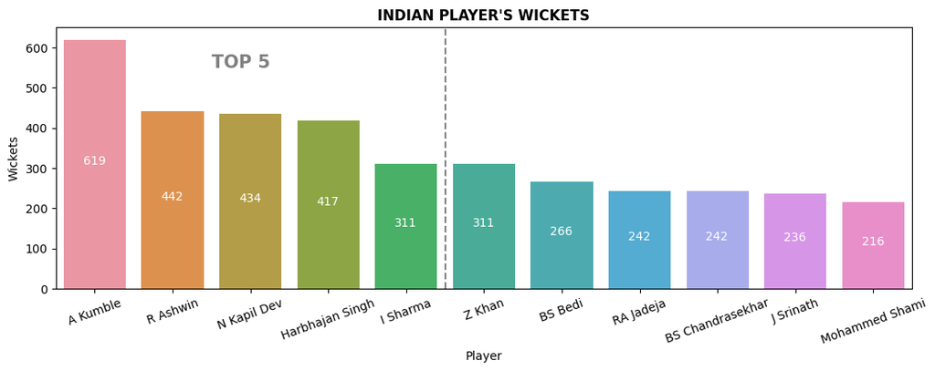

```python
plt.figure(figsize=(13,4))
ax = sns.barplot(x= ind['Player'], y = ind['Wickets'])
plt.title("INDIAN PLAYER'S WICKETS", fontweight= 'bold')
plt.xticks(rotation = 20)
for i in ax.patches:
    ax.text(i.get_x()+0.25, i.get_height()/2, str(int(i.get_height())), color = 'white')
plt.axvline(x = 4.5, color = 'grey', linestyle = "--")
ax.text(1.5,550, 'TOP 5', fontweight = 'bold', fontsize=15, color = 'grey')
```

## Top 5 Economical bowlers of India

```python
indeco = rawdf[rawdf.Country.str.startswith('INDIA')].sort_values(by = ['Economy'])
indeco.head()[['Rank', 'Player', 'Economy']]
```

|  | Rank | Player | Economy |
| --- | --- | --- | --- |
| 40 | 41 | BS Bedi | 2.14 |
| 54 | 55 | RA Jadeja | 2.43 |
| 3 | 4 | A Kumble | 2.69 |
| 55 | 56 | BS Chandrasekhar | 2.70 |
| 7 | 8 | R Ashwin | 2.77 |

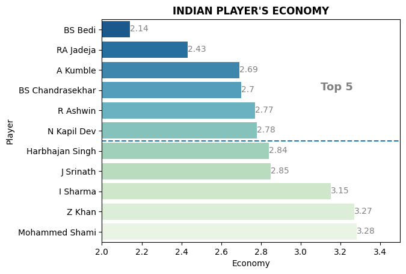

```python
ec = sns.barplot(y= indeco['Player'],x= indeco['Economy'],orient = 'h', palette = 'GnBu_r')
plt.xlim([2,3.50])
for i in ec.patches:
    ec.text(i.get_width(), i.get_y()+0.5, str(i.get_width()), color = 'grey')
ec.axhline(5.5, linestyle = '--')
ec.text(3.1, 3, 'Top 5', size = 13, color = 'grey', fontweight = 'bold')
plt.title("INDIAN PLAYER'S ECONOMY", fontweight = 'bold')
```

## Bowlers from India present in both top 5 Wickets and top 5 Economy table

```python
bestind  = pd.merge(indeco.head(), ind.head(), how = 'inner', on = ["Player"])
bestind.Player
```

```
0    A Kumble
1    R Ashwin
Name: Player, dtype: object
```

A Kumble is the best Indian Test bowler followed by Ravichandra Ashwin. Both of them has better wickets and economy than other bowlers of India.

## Best figure among the best figures:

```python
bfig= []
for i in rawdf['Best Figures']:
    bfig.append(eval(i))
print(bfig)
print(bfig.index(max(bfig)))
print(bfig.index(min(bfig)))
print(max(bfig))
print(min(bfig))
```

[output not shown]

```python
print(rawdf.loc[bfig.index(max(bfig)), ["Country","Player","Wickets","Best Figures"]])
```

```
Country                 ENG
Player          SJ Harmison
Wickets                 226
Best Figures           7/12
Name: 64, dtype: object
```

SJ Harimson's best figure is best among all the best figures as he is less expensive and got more wickets.

## Least best figure among the best figures

```python
print(rawdf.loc[bfig.index(min(bfig)), ["Country","Player","Wickets","Best Figures"]])
```

```
Country                     PAK
Player          Saqlain Mushtaq
Wickets                     208
Best Figures              8/164
Name: 76, dtype: object
```

Saqlain Mushtaq's best figure is the least best figure as he got more wickets but more expensive.

## Correlation

As the order of the data and the Rank is based on Wickets. We are looking for which feature affects the Wickets more.

The factors/features affecting Wickets could be:

1. Career Span
2. Matches
3. Innings
4. Balls
5. Economy

As per the domain of the data, We cannot take Runs as a feature that affects wickets. Even if it does so, we can only say highest wicket takers gives more runs.

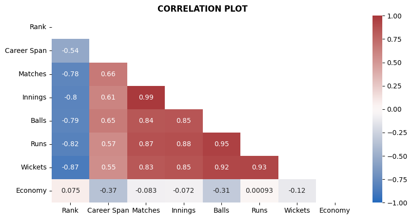

```python
plt.figure(figsize= (10,5))
sns.heatmap(rawdf.corr(), cmap = 'vlag', annot = True, vmin = -1, vmax = 1,
           mask = np.triu(np.ones_like(rawdf.corr())))
plt.title('CORRELATION PLOT', fontweight = 'bold')
```

Matches and Innings have higher positive correlation.

Rank and Wickets have higher negative correlation.

Economy has no strongest correlation with any of the features. It shows that Economy is independent of all other features.

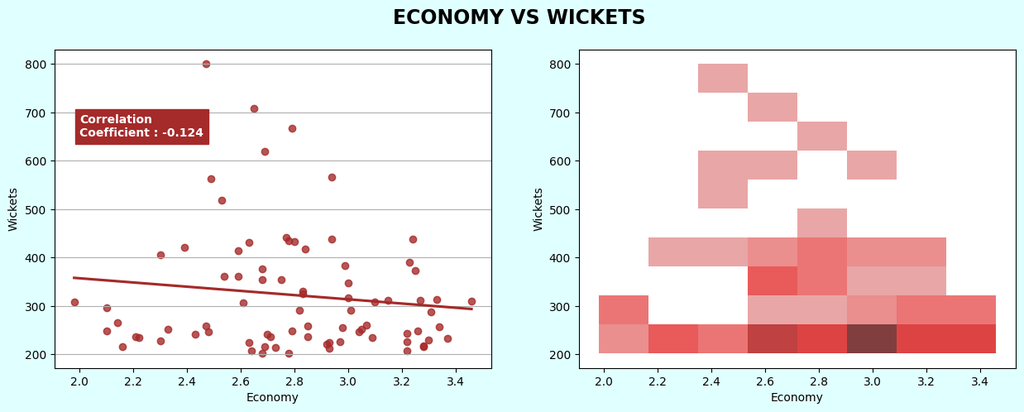

```python
ecowi = round((rawdf[['Economy', 'Wickets']].corr().loc['Economy', 'Wickets']),3)

fig,axs= plt.subplots(1,2, figsize=(15,5))
fig.suptitle('ECONOMY VS WICKETS', fontsize = 17, fontweight = 'bold')
fig.set_facecolor('lightcyan')

sns.regplot(ax= axs[0], x= rawdf["Economy"], y = rawdf['Wickets'], color  = 'brown', ci = None)
axs[0].text(2.0, 650, 'Correlation\nCoefficient : %s'%ecowi, fontdict = dict(backgroundcolor = 'brown', color = 'white', fontweight = 'bold'))
axs[0].grid(axis = 'y')

sns.histplot(ax= axs[1], x= rawdf["Economy"], y = rawdf["Wickets"], color  = 'brown')
```

From the Cricketer's perspective when a bowler bowls economically it pressurize the batsman and he struggles, so the bowler can get wickets by pressurizing the batsman. But, the data here doesn't support this perspective well.

The Scatterplot and histogram shows that the data is scattered everywhere without any pattern and the regression line is almost horizontal and the correlation coefficient is extremely lower(closer to 0) indicating very weak relationship.

So, We can pull out Economy as a feature affecting Wickets.

## Multi-collinearity

First, lets check the highest correlation

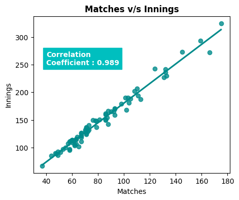

```python
inmat = round((rawdf[['Innings', 'Matches']].corr().loc['Innings', 'Matches']),3)
plt.figure(figsize=(5,4))
inm = sns.regplot(x = rawdf.Matches, y = rawdf.Innings, color = 'darkcyan', ci = None)
plt.title('Matches v/s Innings', fontweight = 'bold')
inm.text(40,250, 'Correlation\nCoefficient : %s'%inmat, fontdict = dict(backgroundcolor = 'c', color = 'white', fontweight = 'bold'))
```

The scatterplot itself clearly proves the highest correlation.

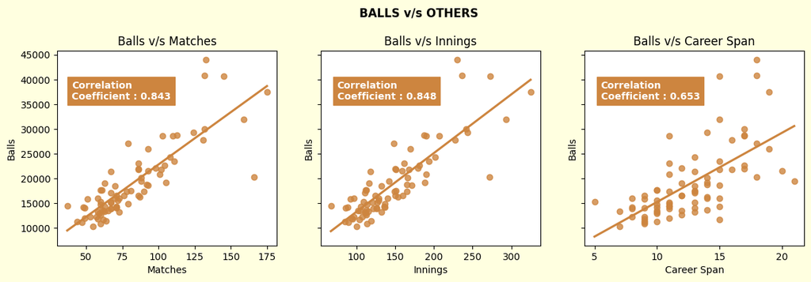

```python
bamat = round((rawdf[['Balls', 'Matches']].corr().loc['Balls', 'Matches']),3)
bainn = round((rawdf[['Innings', 'Balls']].corr().loc['Innings', 'Balls']),3)
bacs = round((rawdf[['Career Span', 'Balls']].corr().loc['Career Span', 'Balls']),3)


fig,axs = plt.subplots(1,3, figsize=(14,4), sharey = True)
fig.suptitle('BALLS v/s OTHERS', fontweight = 'bold')
plt.subplots_adjust(top = 0.82)
fig.set_facecolor('lightyellow')

sns.regplot(ax= axs[0],x = rawdf.Matches, y = rawdf.Balls, color = 'peru', ci = None).set_title('Balls v/s Matches')
axs[0].text(40,36000, 'Correlation\nCoefficient : %s'%bamat, fontdict = dict(backgroundcolor = 'peru', color = 'white', fontweight = 'bold'))

sns.regplot(ax= axs[1], x = rawdf.Innings, y = rawdf.Balls, color = 'peru', ci = None).set_title('Balls v/s Innings')
axs[1].text(75,36000, 'Correlation\nCoefficient : %s'%bainn, fontdict = dict(backgroundcolor = 'peru', color = 'white', fontweight = 'bold'))

sns.regplot(ax = axs[2], y= rawdf.Balls, x = rawdf['Career Span'], color = 'peru', ci = None).set_title('Balls v/s Career Span')
axs[2].text(5.5,36000, 'Correlation\nCoefficient : %s'%bacs, fontdict = dict(backgroundcolor = 'peru', color = 'white', fontweight = 'bold'))
```

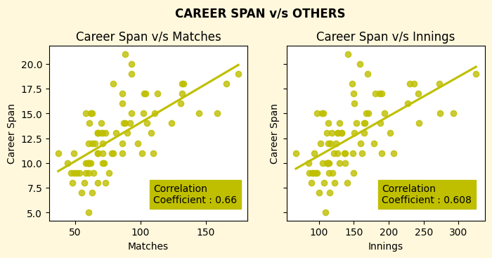

```python
csma = rawdf[['Career Span', 'Matches']].corr().loc['Career Span', 'Matches']
csin = rawdf[['Career Span', 'Innings']].corr().loc['Career Span', 'Innings']

fig,axs = plt.subplots(1,2, figsize = (8,3.5), sharey = True)
fig.suptitle('CAREER SPAN v/s OTHERS', fontweight = 'bold')
plt.subplots_adjust(top = 0.82)
fig.set_facecolor('cornsilk')

sns.regplot(ax = axs[0], x = rawdf['Matches'], y = rawdf['Career Span'], color = 'y', ci = None).set_title('Career Span v/s Matches')
axs[0].text(110, 6, 'Correlation\nCoefficient : '+str(round((csma),3)), backgroundcolor= 'y')
sns.regplot(ax = axs[1], x= rawdf.Innings, y = rawdf['Career Span'], color = 'y', ci = None).set_title('Career Span v/s Innings')
axs[1].text(190, 6, 'Correlation\nCoefficient : '+str(round((csin),3)), backgroundcolor= 'y')
```

#### Though the factors have collinearity among them, let's check all of them with wickets.

# Let's see which of the following factors affects the wickets most

The potential factors/features affecting Wickets are:

1. Career span
2. Innings
3. Matches
4. Balls

## Relationship between Career Span and Wickets

```python
cswic = round((rawdf[['Career Span', 'Wickets']].corr().loc['Career Span', 'Wickets']),3)
```

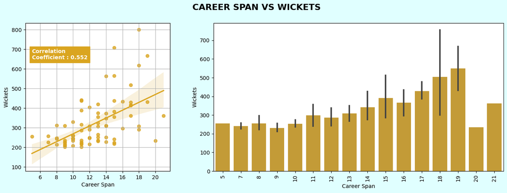

```python
fig,axes = plt.subplots(1,2, figsize = (16,5), gridspec_kw={'width_ratios': [1, 2], 'wspace': 0.2})
fig.suptitle("CAREER SPAN VS WICKETS", fontsize = 16, fontweight = 'bold')
fig.set_facecolor('lightcyan')

sns.regplot(ax=axes[0], x = rawdf['Career Span'], y = rawdf.Wickets, color = 'goldenrod')
axes[0].text(5, 650, 'Correlation\nCoefficient : %s'%cswic, fontdict = dict(backgroundcolor = 'goldenrod', color = 'white', fontweight = 'bold'))
axes[0].grid()

sns.barplot(ax=axes[1], x = rawdf['Career Span'], y = rawdf.Wickets, color = 'goldenrod')
axes[1].tick_params('x', rotation = 90)
```

Career Span has positive correlation with Wickets with correlation coefficient of 0.552. It is neither a weak nor a strong relationship. The bar graph is not rising that much.

## Relaionship between Innings and Wickets

```python
inwi = round((rawdf[['Wickets', 'Innings']].corr().loc['Wickets', 'Innings']),3)
```

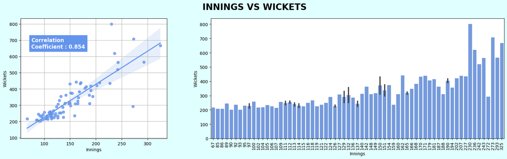

```python
fig, axes = plt.subplots(1,2, figsize=(20,5), gridspec_kw={'width_ratios': [1,2], 'wspace': 0.2})
fig.suptitle('INNINGS VS WICKETS', fontsize = 20, fontweight = 'bold')
fig.set_facecolor('lightcyan')

sns.regplot(ax = axes[0], x= rawdf['Innings'], y = rawdf['Wickets'], color = 'cornflowerblue')
axes[0].text(75, 650, 'Correlation\nCoefficient : %s'%inwi ,fontdict = dict(backgroundcolor = 'cornflowerblue', color = 'white',fontsize = 12, fontweight = 'bold'))
axes[0].grid()

sns.barplot(ax = axes[1], x= rawdf['Innings'], y = rawdf['Wickets'], color = 'cornflowerblue')
axes[1].tick_params('x', rotation = 90)
```

Innings is positively correlated with Wickets with correlation coefficient of 0.854. It indicates strong positive correlation. The bar graph is also appears to be rising from the minimum.

## Relationship between Matches and Wickets

```python
matwic = round((rawdf[['Wickets', 'Matches']].corr().loc['Wickets', 'Matches']),3)
```

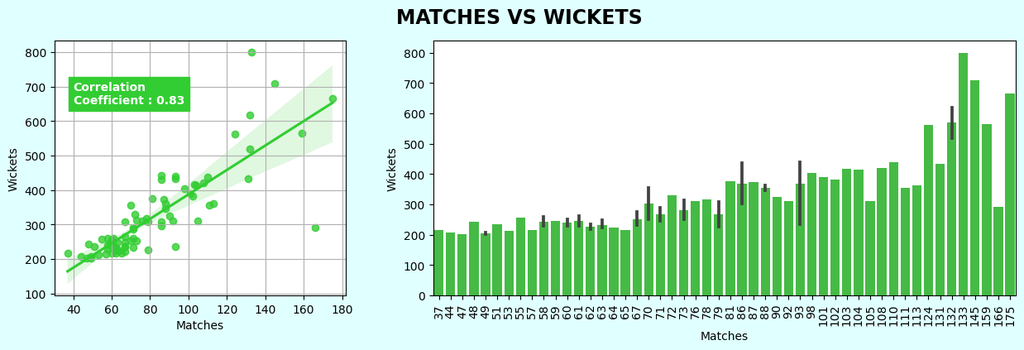

```python
fig,axs= plt.subplots(1,2, figsize=(15,4), gridspec_kw={'width_ratios': [1,2], 'wspace': 0.2})
fig.suptitle('MATCHES VS WICKETS', fontsize = 17, fontweight = 'bold')
fig.set_facecolor('lightcyan')

sns.regplot(ax= axs[0], x= rawdf["Matches"], y = rawdf['Wickets'], color  = 'limegreen')
axs[0].text(40, 650, 'Correlation\nCoefficient : %s'%matwic, fontdict = dict(backgroundcolor = 'limegreen', color = 'white', fontweight = 'bold'))
axs[0].grid()

sns.barplot(ax = axs[1], x= rawdf['Matches'], y = rawdf['Wickets'], color = 'limegreen')
axs[1].tick_params('x', rotation = 90)
```

Matches is also positvely correlated with Wickets with correlation coefficient of 0.83. This is also indicates a strong positive relationship as Innings do. The bar graph is also rising from the minimum.

## Relationship between Balls bowled and Wickets

```python
bawi =  round((rawdf[['Wickets', 'Balls']].corr().loc['Wickets', 'Balls']),3)
```

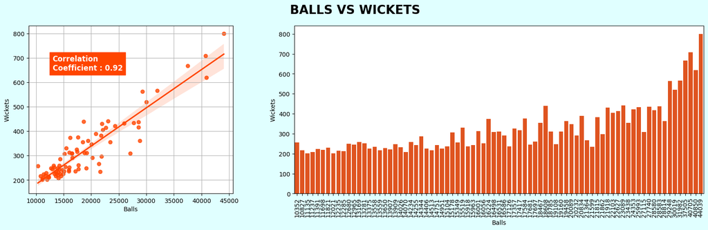

```python
fig, axes = plt.subplots(1,2, figsize=(20,5), gridspec_kw={'width_ratios': [1,2], 'wspace': 0.2})
fig.suptitle('BALLS VS WICKETS', fontsize = 20, fontweight = 'bold')
fig.set_facecolor('lightcyan')

sns.regplot(ax = axes[0], x= rawdf['Balls'], y = rawdf['Wickets'], color = 'orangered')
axes[0].text(13000, 650, 'Correlation\nCoefficient : %s'%bawi, fontdict = dict(backgroundcolor = 'orangered', color = 'white', fontsize = 12, fontweight = 'bold'))
axes[0].grid()

sns.barplot(ax = axes[1], x= rawdf['Balls'], y = rawdf['Wickets'], color = 'orangered')
axes[1].tick_params('x', rotation = 90)
```

The above plot shows the highest correlation coefficient 0.92 and a very strong positive relationship. Balls have highest correlation with Wickets than that of other factors with Wickets.

The bar graph is clearly appears as rising from the minimum.

## Comparing the factors

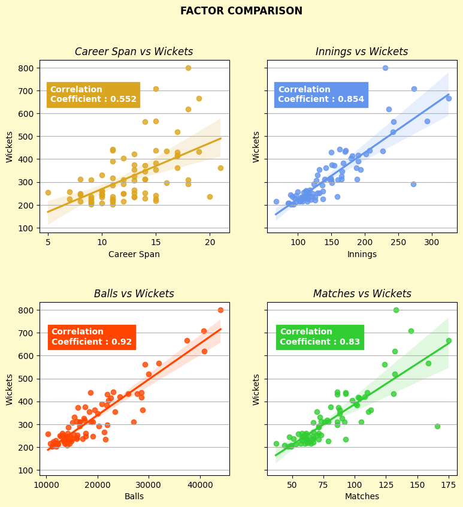

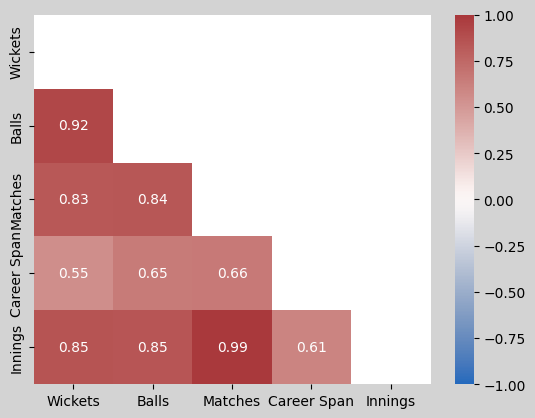

```python
fig,axes= plt.subplots(2,2, figsize=(9,9), gridspec_kw = dict(hspace= 0.4), sharey = True)
fig.suptitle('FACTOR COMPARISON', fontweight = 'bold')
fig.set_facecolor('lemonchiffon')

sns.regplot(ax=axes[0,0], x = rawdf['Career Span'], y = rawdf.Wickets, color = 'goldenrod')
axes[0,0].text(5.2, 650, 'Correlation\nCoefficient : %s'%cswic, fontdict = dict(backgroundcolor = 'goldenrod', color = 'white', fontweight = 'bold'))
axes[0,0].grid(axis = 'y')
axes[0,0].set_title('Career Span vs Wickets', fontstyle = 'italic')

sns.regplot(ax = axes[0,1], x= rawdf['Innings'], y = rawdf['Wickets'], color = 'cornflowerblue')
axes[0,1].text(70, 650, 'Correlation\nCoefficient : %s'%inwi ,fontdict = dict(backgroundcolor = 'cornflowerblue', color = 'white', fontweight = 'bold'))
axes[0,1].grid(axis = 'y')
axes[0,1].set_title('Innings vs Wickets', fontstyle = 'italic')

sns.regplot(ax = axes[1,0], x= rawdf['Balls'], y = rawdf['Wickets'], color = 'orangered')
axes[1,0].text(11000, 650, 'Correlation\nCoefficient : %s'%bawi, fontdict = dict(backgroundcolor = 'orangered', color = 'white', fontweight = 'bold'))
axes[1,0].grid(axis = 'y')
axes[1,0].set_title('Balls vs Wickets', fontstyle = 'italic')

sns.regplot(ax= axes[1,1], x= rawdf["Matches"], y = rawdf['Wickets'], color  = 'limegreen')
axes[1,1].text(40, 650, 'Correlation\nCoefficient : %s'%matwic, fontdict = dict(backgroundcolor = 'limegreen', color = 'white', fontweight = 'bold'))
axes[1,1].grid(axis = 'y')
axes[1,1].set_title('Matches vs Wickets', fontstyle = 'italic')

plt.figure(facecolor = 'lightgrey')
sns.heatmap((rawdf[['Wickets', 'Balls', 'Matches', 'Career Span', 'Innings']]).corr(), vmin= -1, vmax= 1,cmap = 'vlag', annot = True,
           mask = np.triu(np.ones_like((rawdf[['Wickets', 'Balls', 'Matches', 'Career Span', 'Innings']]).corr())))
```

From the above plot, Balls have higher correlation(0.92) with Wickets than other factors and have a very strong positive relationship. More balls bowled more wickets possible.

Next strong positive relationship is between Innings and Wickets(0.85) followed by the correlation between Matches and Wickets(0.83) which is also a strong positive relationship.

The least positive relationship is between Career Span and Wickets(0.55).

## Multi-collinearity chart

Despite the strong positive correlation with Wickets. There are some Correlation among the factors/features themselves.

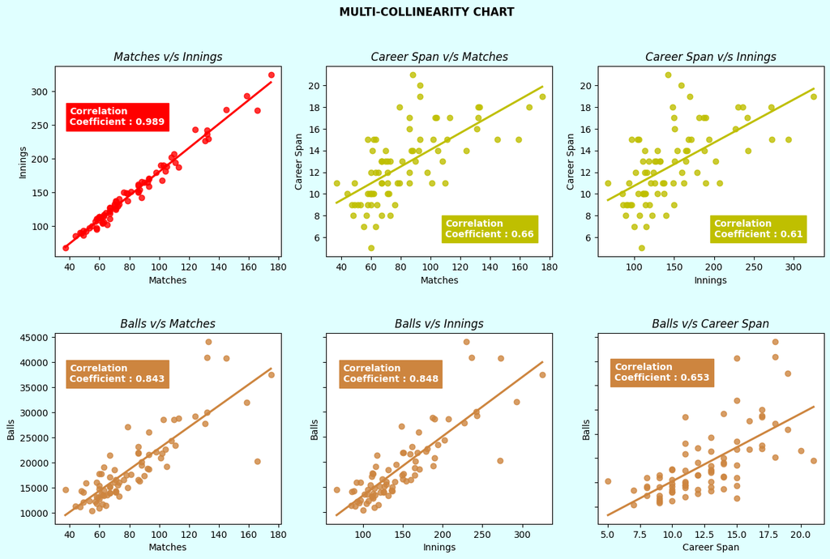

```python
fig, axs = plt.subplots(2,3, figsize=(15,9))
fig.suptitle('MULTI-COLLINEARITY CHART', fontweight = 'bold')
fig.set_facecolor('lightcyan')
plt.subplots_adjust(hspace = 0.4)

sns.regplot(ax = axs[0,0], x = rawdf.Matches, y = rawdf.Innings, color = 'red', ci = None).set_title('Matches v/s Innings', style = 'italic')
axs[0,0].text(40,250, 'Correlation\nCoefficient : %s'%inmat, fontdict = dict(backgroundcolor = 'red', color = 'white', fontweight = 'bold'))

sns.regplot(ax = axs[0,1], x = rawdf['Matches'], y = rawdf['Career Span'], color = 'y', ci = None).set_title('Career Span v/s Matches', style = 'italic')
axs[0,1].text(110, 6, 'Correlation\nCoefficient : '+str(round((csma),3)), color = 'white', backgroundcolor = 'y', fontweight = 'bold')

sns.regplot(ax = axs[0,2], x= rawdf.Innings, y = rawdf['Career Span'], color = 'y', ci = None).set_title('Career Span v/s Innings', style = 'italic')
axs[0,2].text(200, 6, 'Correlation\nCoefficient : '+str(round((csin),2)), color = 'white', backgroundcolor = 'y', fontweight = 'bold')


sns.regplot(ax= axs[1,0],x = rawdf.Matches, y = rawdf.Balls, color = 'peru', ci = None).set_title('Balls v/s Matches', style = 'italic')
axs[1,0].text(40,36000, 'Correlation\nCoefficient : %s'%bamat, fontdict = dict(backgroundcolor = 'peru', color = 'white', fontweight = 'bold'))

sns.regplot(ax= axs[1,1], x = rawdf.Innings, y = rawdf.Balls, color = 'peru', ci = None).set_title('Balls v/s Innings', style = 'italic')
axs[1,1].text(75,36000, 'Correlation\nCoefficient : %s'%bainn, fontdict = dict(backgroundcolor = 'peru', color = 'white', fontweight = 'bold'))
axs[1,1].tick_params('y', labelleft = False)

sns.regplot(ax = axs[1,2], y= rawdf.Balls, x = rawdf['Career Span'], color = 'peru', ci = None).set_title('Balls v/s Career Span', style = 'italic')
axs[1,2].text(5.5,36000, 'Correlation\nCoefficient : %s'%bacs, fontdict = dict(backgroundcolor = 'peru', color = 'white', fontweight = 'bold'))
axs[1,2].tick_params('y', labelleft = False)
```

Matches and Innings have extremely higher correlation(0.989) that needs to be dealt with.

Balls also have strong positive correlation with Matches and Innings(0.843 and 0.848 respectively).

Career span is the only factor that is bit away from Multi-collinearity. Career Span have moderate positive relationship with other factors such as Innings, Matches and Balls(0.61, 0.66 and 0.653 respectively).

# CONCLUSION:

## 8) WestIndies have Economical bowlers.

## 9) Almost all Distribution of other features are right-skewed.

## 10) Most experienced bowler- Imran Khan(PAK); Most matches & innings played- Jimmy Anderson(ENG); Most balls bowled- Muthiah Muralidaran(SL); Least runs given- VD Philander(SA).

## 11) Anil Kumble is the best test bowler in India followed by Ashwin.

## 12) BS Bedi is the Economical bowler in India.

## 13) SJ Harimson from England have the best figure among the Best figures and Saqlain Mushtaq is the least best figure among the Best figures.

## 14) Correlation between Matches and Innings is the highest and Runs and Economy is the lowest correlation.

## 15) Economy as a feature is not strongly correlated any other feature.

## 16) Balls is the predominant factor/feature affecting Wickets as it is highly correlated with Wickets.

## 17) Career Span is the least affecting factor/feature as it is has low correlation with Wickets.

## 18) Multi-Collinearity is prevalent among the factors/features. However, the feature Career Span is moderately correlated with other features.

# THANK YOU

```
                                                                                                 Project by VIGNESH V G
                                                                                                 vigneshvg100@gmail.com
```